# **Evaluación de modelos para la predicción diaria de accidentes viales con Gravedad: Solo daños**

Alexis A. Arenas Bustamante, Juan E. Arroyave Duque, William A. Jovel Tamayo, Manuela Londoño Ocampo.* Curso de Analítica Predictiva Universidad Nacional de Colombia Facultad de Minas Medellín

Septiembre de 2019

```r
library(dplyr) # data wrangling
library(ranger)
library(caret)
library(corrplot)
library(rsample)     # data splitting
library(rpart)       # performing regression trees
library(rpart.plot)  # plotting regression trees
library(ipred)       # bagging
require(MASS)
library(randomForest)
library(tidyverse)
library(ggpubr)
```

Se consideran tres modelos para la predicción diaria de los accidentes viales con solo daños: Regresión lineal, Árbol de regresión y Random Forest. A continuación se presenta la evaluación de cada uno:

# 1 **Dataset propuesto para el modelo diaria de accidentalidad vial : Solo Daños**

|  | PERIODO | SOLO_DANOS | ENERO_1 | PUENTE_REYES | SEMANA_SANTA | DIA_MADRES | DIA_PADRES | COLOMBIAMODA | FERIA_FLORES | DIC_24 | DIC_25 | DIC_31 | FESTIVOS | Martes | Miercoles | Jueves | Viernes | Sabado | Domingo |
| --- | --- | --- | --- | --- | --- | --- | --- | --- | --- | --- | --- | --- | --- | --- | --- | --- | --- | --- | --- |
| 1 | 1 | 18 | 1 | 0 | 0 | 0 | 0 | 0 | 0 | 0 | 0 | 0 | 1 | 0 | 1 | 0 | 0 | 0 | 0 |
| 2 | 1 | 31 | 0 | 0 | 0 | 0 | 0 | 0 | 0 | 0 | 0 | 0 | 0 | 0 | 0 | 1 | 0 | 0 | 0 |
| 3 | 1 | 43 | 0 | 0 | 0 | 0 | 0 | 0 | 0 | 0 | 0 | 0 | 0 | 0 | 0 | 0 | 1 | 0 | 0 |
| 4 | 1 | 27 | 0 | 0 | 0 | 0 | 0 | 0 | 0 | 0 | 0 | 0 | 0 | 0 | 0 | 0 | 0 | 1 | 0 |
| 5 | 1 | 32 | 0 | 0 | 0 | 0 | 0 | 0 | 0 | 0 | 0 | 0 | 0 | 0 | 0 | 0 | 0 | 0 | 1 |
| 6 | 1 | 16 | 0 | 1 | 0 | 0 | 0 | 0 | 0 | 0 | 0 | 0 | 1 | 0 | 0 | 0 | 0 | 0 | 0 |

# 2 **Estadísticas Descriptivas**

## 2.1 **Summary del conjunto de datos**

```
##     PERIODO      SOLO_DANOS       ENERO_1          PUENTE_REYES
##  Min.   :1.0   Min.   :  5.0   Min.   :0.000000   Min.   :0.000000
##  1st Qu.:1.0   1st Qu.: 43.0   1st Qu.:0.000000   1st Qu.:0.000000
##  Median :1.0   Median : 56.0   Median :0.000000   Median :0.000000
##  Mean   :1.2   Mean   : 52.8   Mean   :0.002738   Mean   :0.002738
##  3rd Qu.:1.0   3rd Qu.: 65.0   3rd Qu.:0.000000   3rd Qu.:0.000000
##  Max.   :2.0   Max.   :103.0   Max.   :1.000000   Max.   :1.000000
##   SEMANA_SANTA       DIA_MADRES         DIA_PADRES        COLOMBIAMODA
##  Min.   :0.00000   Min.   :0.000000   Min.   :0.000000   Min.   :0.000000
##  1st Qu.:0.00000   1st Qu.:0.000000   1st Qu.:0.000000   1st Qu.:0.000000
##  Median :0.00000   Median :0.000000   Median :0.000000   Median :0.000000
##  Mean   :0.01095   Mean   :0.002738   Mean   :0.002738   Mean   :0.008215
##  3rd Qu.:0.00000   3rd Qu.:0.000000   3rd Qu.:0.000000   3rd Qu.:0.000000
##  Max.   :1.00000   Max.   :1.000000   Max.   :1.000000   Max.   :1.000000
##   FERIA_FLORES         DIC_24             DIC_25             DIC_31
##  Min.   :0.00000   Min.   :0.000000   Min.   :0.000000   Min.   :0.000000
##  1st Qu.:0.00000   1st Qu.:0.000000   1st Qu.:0.000000   1st Qu.:0.000000
##  Median :0.00000   Median :0.000000   Median :0.000000   Median :0.000000
##  Mean   :0.02738   Mean   :0.002738   Mean   :0.002738   Mean   :0.002738
##  3rd Qu.:0.00000   3rd Qu.:0.000000   3rd Qu.:0.000000   3rd Qu.:0.000000
##  Max.   :1.00000   Max.   :1.000000   Max.   :1.000000   Max.   :1.000000
##     FESTIVOS           Martes         Miercoles          Jueves
##  Min.   :0.00000   Min.   :0.0000   Min.   :0.0000   Min.   :0.0000
##  1st Qu.:0.00000   1st Qu.:0.0000   1st Qu.:0.0000   1st Qu.:0.0000
##  Median :0.00000   Median :0.0000   Median :0.0000   Median :0.0000
##  Mean   :0.05312   Mean   :0.1424   Mean   :0.1429   Mean   :0.1429
##  3rd Qu.:0.00000   3rd Qu.:0.0000   3rd Qu.:0.0000   3rd Qu.:0.0000
##  Max.   :1.00000   Max.   :1.0000   Max.   :1.0000   Max.   :1.0000
##     Viernes           Sabado          Domingo
##  Min.   :0.0000   Min.   :0.0000   Min.   :0.0000
##  1st Qu.:0.0000   1st Qu.:0.0000   1st Qu.:0.0000
##  Median :0.0000   Median :0.0000   Median :0.0000
##  Mean   :0.1429   Mean   :0.1429   Mean   :0.1429
##  3rd Qu.:0.0000   3rd Qu.:0.0000   3rd Qu.:0.0000
##  Max.   :1.0000   Max.   :1.0000   Max.   :1.0000
```

## 2.2 **Histograma de la variable dependiente**

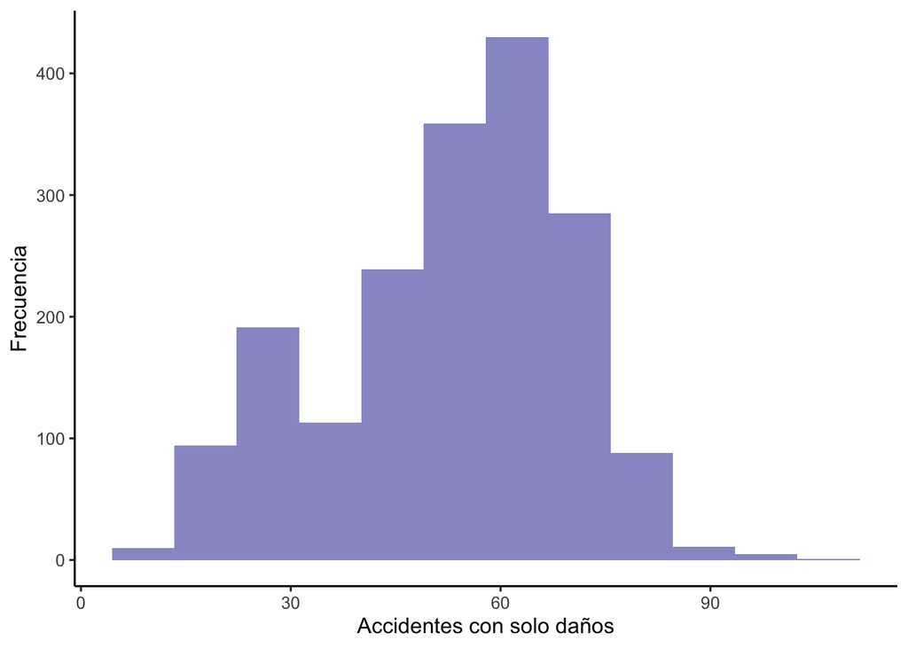

## 2.3 **Correlación entre variables consideradas**

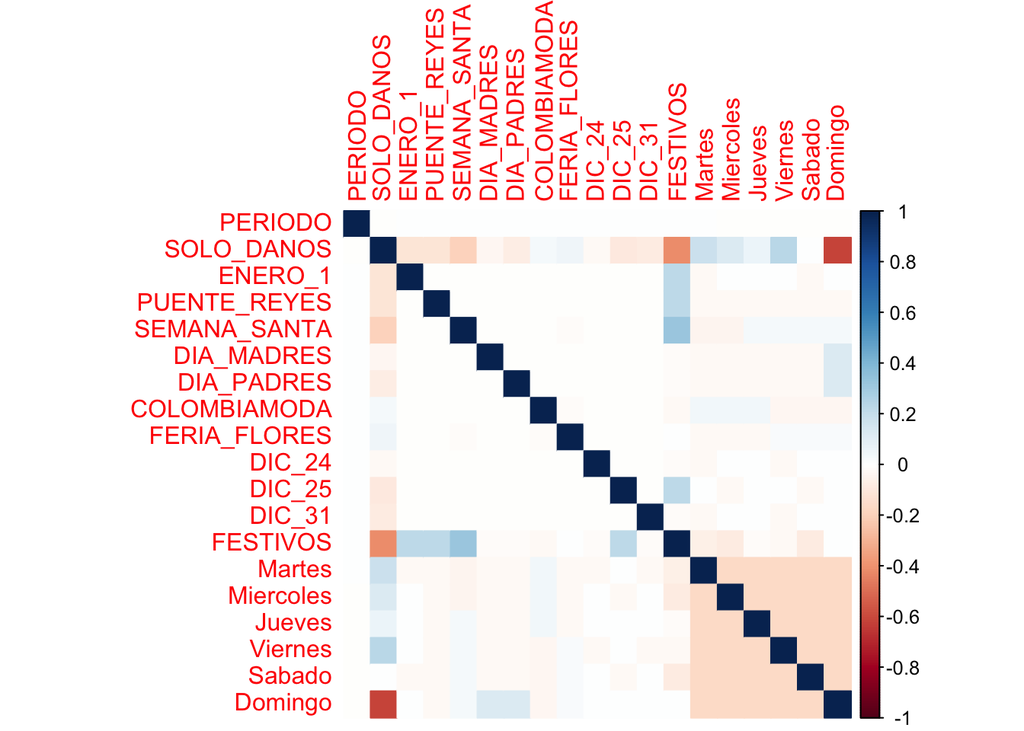

Se puede observar que las variables mas correlacionada con la cantidad de accidentes diarios con solo daños son el dia Domingo y Festivos. En cada uno de los modelos se identificará la importancia de las variables, de modo que solo se incluyan aquellas que tengan una influencia significativa sobre la variables dependiente. El periodo no hará parte de ningún modelo puesto que solo se usa para la partición de los datos en conjuntos de entrenamiento y validación.

# 3 **Partición de los datos conjuntos de train y test**

Para la validación se usaran los datos de accidentes viales ocurridos en el año 2018.

Datos de Train: Se cuenta 1461 observaciones para el entrenamiento de los modelos

```
## [1] 1461   19
```

Datos de Test: Se cuenta con 365 observaciones para la validación de los modelos

```
## [1] 365  19
```

Una vez realizada la partición de los datos, se procede con la eliminación de la variable PERIODO en ambos datasets.

```r
solo_danos_train <- dplyr :: select(solo_danos_train, -PERIODO)
solo_danos_test <- dplyr :: select(solo_danos_test, -PERIODO)
```

# 4 **Modelo de predicción considerados**

## 4.1 **Regresión Lineal**

**Entrenamiento del modelo**

```r
regresion_1 <- lm(SOLO_DANOS ~. -DIA_PADRES -COLOMBIAMODA, data = solo_danos_train)
summary(regresion_1)
```

```
##
## Call:
## lm(formula = SOLO_DANOS ~ . - DIA_PADRES - COLOMBIAMODA, data = solo_danos_train)
##
## Residuals:
##     Min      1Q  Median      3Q     Max
## -43.360  -6.854  -0.360   7.065  43.280
##
## Coefficients:
##              Estimate Std. Error t value Pr(>|t|)
## (Intercept)   58.7198     0.8043  73.010  < 2e-16 ***
## ENERO_1       -7.8730     5.5784  -1.411  0.15836
## PUENTE_REYES -14.8492     5.5529  -2.674  0.00758 **
## SEMANA_SANTA  -8.5670     2.9326  -2.921  0.00354 **
## DIA_MADRES    10.8147     5.4103   1.999  0.04581 *
## FERIA_FLORES   7.4135     1.7218   4.306 1.78e-05 ***
## DIC_24        -9.2761     5.3705  -1.727  0.08434 .
## DIC_25        -3.0337     5.5599  -0.546  0.58540
## DIC_31       -22.7761     5.3705  -4.241 2.37e-05 ***
## FESTIVOS     -28.3706     1.5408 -18.413  < 2e-16 ***
## Martes         2.1346     1.0926   1.954  0.05092 .
## Miercoles     -0.6432     1.0922  -0.589  0.55604
## Jueves        -1.3596     1.0857  -1.252  0.21069
## Viernes        4.8823     1.0893   4.482 7.98e-06 ***
## Sabado        -5.9877     1.1016  -5.435 6.41e-08 ***
## Domingo      -29.7845     1.0864 -27.417  < 2e-16 ***
## ---
## Signif. codes:  0 '***' 0.001 '**' 0.01 '*' 0.05 '.' 0.1 ' ' 1
##
## Residual standard error: 10.71 on 1445 degrees of freedom
## Multiple R-squared:  0.5991, Adjusted R-squared:  0.5949
## F-statistic:   144 on 15 and 1445 DF,  p-value: < 2.2e-16
```

Se puede observar que la mayoría de variables son significativas para el modelo, a pesar de esto las métricas de ajuste no son muy buenas, por su parte el R-squared indica que el modelo logra explica el 59.91 % de la accidentalidad diaria con gravedad de solo daños. El valor P del estadístico F en este caso es significativo.

**Métricas de Bondad para regresión lineal**

| RMSE_Train | Rsquared_Train | RMSE_Test | Rsquared_Test |
| --- | --- | --- | --- |
| 10.6552 | 0.599088 | 11.16115 | 0.551276 |

Comparando las métricas consideradas tanto para el entrenamiento como para la validación del modelo, se observa que en ambas se alcanzaron valores cercanos al 60%; en cuanto al RMSE es posible identificar que la diferencia entre los conjuntos de entrenamiento y test es del 4.6 %, esto indica que a pesar de que no tiene mucha capacidad predictiva, el modelo no presenta problemas de sobre entrenamiento.

Se eliminan del dataset las variables que no tuvieron significacia para el modelo de rehgresión lineal:

```r
solo_danos_train <- dplyr :: select(solo_danos_train, -DIA_PADRES, -COLOMBIAMODA)
solo_danos_test <- dplyr :: select(solo_danos_test, -DIA_PADRES, -COLOMBIAMODA)
```

**Ajuste de las predicciones vs valores reales**

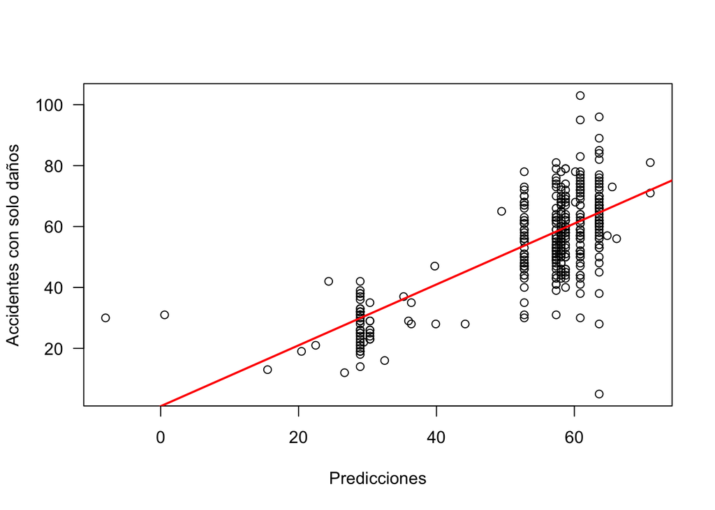

```r
plot(y_pred_test_sd, solo_danos_test$SOLO_DANOS,las=1, xlab="Predicciones", ylab = "Accidentes con solo daños")
abline(a=1,b=1,lwd=2,col="red")
```

En el gráfico de dispersión se puede observar de mejor manera la pobre capacidad de predicción que obtuvo el modelo para la accidentalidad vial diaria con solo daños.

## 4.2 **Árbol Regresor**

**Entrenamiento del modelo**

Se toma el modelo mas simple para el árbol regresor, a partir de este se realizará una búsqueda tipo grid search, de parámetros de restricción óptimos. Se definen ademas funciones para extraer el mínimo error asociado con el valor óptimo de costo de complejidad (CP) de cada modelo y el valor óptimo CP.

```r
set.seed(123)
dt_sd <- rpart(
  formula = SOLO_DANOS ~ .,
  data    = solo_danos_train,
  method  = "anova"
  )
```

**Representación gráfica del árbol regresor sin tuning**

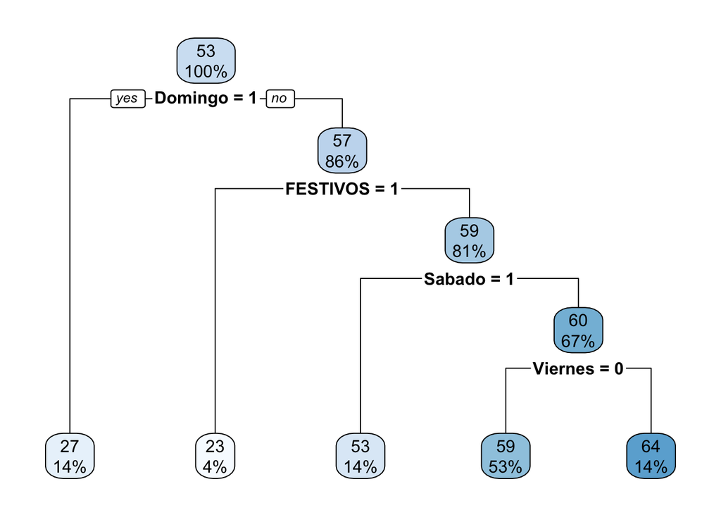

**Ajuste de parámetro de restricción para el árbol regresor**

Se realiza una búsqueda de los parámetros óptimos de minsplit y maxdepth para el árbol regresor:

En la siguiente gráfica se puede observar el numero optimo de nodos identificado por el modelo que reduce el error asociado. Este sera el punto de partida para definir entre que valores puede variar el parámetro de profundidad del árbol. Vemos que este valor es de 4 divisiones y 5 nodos finales.

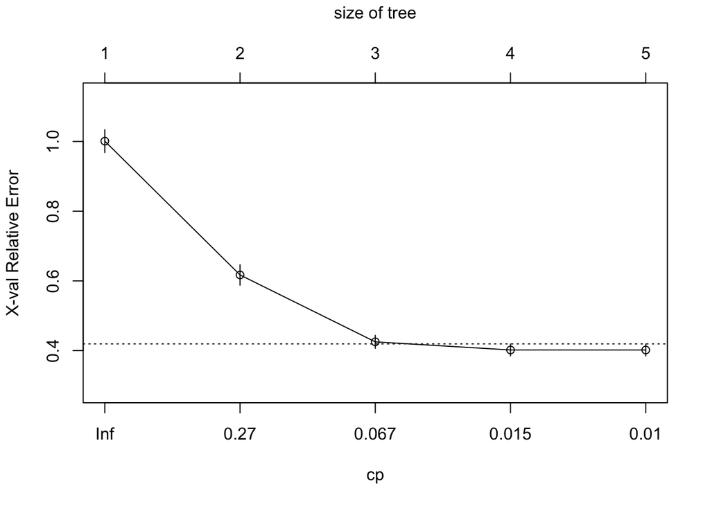

```r
plotcp(dt_sd)
```

```r
dt_sd2 <- rpart(
    formula = SOLO_DANOS ~ .,
    data    = solo_danos_train,
    method  = "anova",
    control = list(cp = 0, xval = 10)
)
```

```r
dt_sd$cptable
```

```
##           CP nsplit rel error    xerror       xstd
## 1 0.38366022      0 1.0000000 1.0010235 0.03286706
## 2 0.19210515      1 0.6163398 0.6170025 0.02939485
## 3 0.02366279      2 0.4242346 0.4251023 0.01867179
## 4 0.01012890      3 0.4005718 0.4017807 0.01725613
## 5 0.01000000      4 0.3904429 0.4017193 0.01748334
```

El siguiente código define una función grid para la búsqueda de diferentes combinaciones de minsplit y maxdepth. También las funciones que extraen el optimo cp y el mínimo error asociado.

```r
hyper_grid_sd <- expand.grid(
  minsplit = seq(2, 20, 1),
  maxdepth = seq(2, 20, 1)
)

models_sd <- list()

for (i in 1:nrow(hyper_grid_sd)) {

  # get minsplit, maxdepth values at row i
  minsplit <- hyper_grid_sd$minsplit[i]
  maxdepth <- hyper_grid_sd$maxdepth[i]

  # train a model and store in the list
  models_sd[[i]] <- rpart(
    formula = SOLO_DANOS ~ .,
    data    = solo_danos_train,
    method  = "anova",
    control = list(minsplit = minsplit, maxdepth = maxdepth)
    )
}

# function to get optimal cp
get_cp <- function(x) {
  min    <- which.min(x$cptable[, "xerror"])
  cp <- x$cptable[min, "CP"]
}

# function to get minimum error
get_min_error <- function(x) {
  min    <- which.min(x$cptable[, "xerror"])
  xerror <- x$cptable[min, "xerror"]
}
```

Agregaremos los resultados de la búsqueda a la grilla de hyper-parámetros y filtraremos los 5 valores con error mínimo.

```r
hyper_grid_sd %>%
  mutate(
    cp    = purrr::map_dbl(models_sd, get_cp),
    error = purrr::map_dbl(models_sd, get_min_error)
    ) %>%
  arrange(error) %>%
  top_n(-5, wt = error)
```

| minsplit | maxdepth | cp | error |
| --- | --- | --- | --- |
| 7 | 5 | 0.01 | 0.3974123 |
| 15 | 18 | 0.01 | 0.3977830 |
| 7 | 19 | 0.01 | 0.3977905 |
| 12 | 6 | 0.01 | 0.3978379 |
| 17 | 16 | 0.01 | 0.3978720 |

Vemos que el error se redujo a 0.397, lo cual indica mejores modelos en comparación con el modelo inicial. Se entrena el árbol regresor con las combinaciones que encabezan los resultados anteriores:

```r
optimal_tree_sd1 <- rpart(
    formula = SOLO_DANOS ~ .,
    data    = solo_danos_train,
    method  = "anova",
    control = list(minsplit = 7, maxdepth = 5, cp = 0.01)
    )
```

**Métricas de Bondad para el mejor árbol regresor**

```r
pred_dt1_train = predict(optimal_tree_sd1, newdata=solo_danos_train)
pred_dt1_test = predict(optimal_tree_sd1, newdata=solo_danos_test)

dt_sd_op1 <- data.frame(RMSE_Train = RMSE(pred_dt1_train, solo_danos_train$SOLO_DANOS),
                    Rsquared_Train = R2(pred_dt1_train, solo_danos_train$SOLO_DANOS),
                    RMSE_Test = RMSE(pred_dt1_test, solo_danos_test$SOLO_DANOS),
                    Rsquared_Test = R2(pred_dt1_test, solo_danos_test$SOLO_DANOS))

dt_sd_op1
```

| RMSE_Train | Rsquared_Train | RMSE_Test | Rsquared_Test |
| --- | --- | --- | --- |
| 10.51515 | 0.6095571 | 11.2029 | 0.5507908 |

**Mejor árbol regresor obtenido**

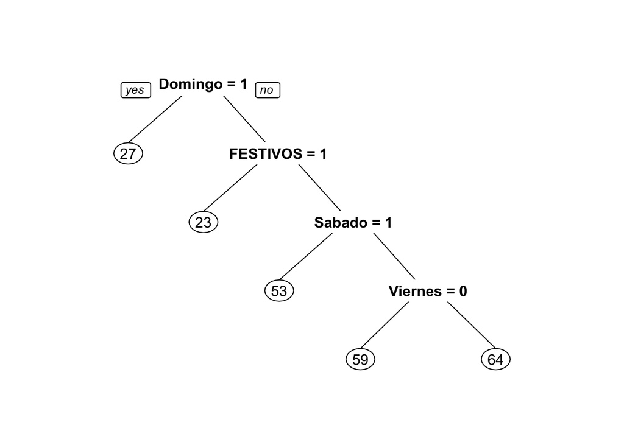

## 4.3 **Random Forest**

**Entrenamiento del modelo**

Se toma el modelo mas simple, a partir de este se realizará una búsqueda tipo grid search de los hiper parámetros óptimos, mediante el uso de la librería Range. Se analizaron en total 1320 modelos diferentes con variaciones en mtry, mínimo tamaño de muestras en el nodo, y tamaño de la muestra.

```r
set.seed(101)
rf_sd = randomForest(SOLO_DANOS ~ ., data = solo_danos_test)
rf_sd
```

```
##
## Call:
##  randomForest(formula = SOLO_DANOS ~ ., data = solo_danos_test)
##                Type of random forest: regression
##                      Number of trees: 500
## No. of variables tried at each split: 5
##
##           Mean of squared residuals: 125.7771
##                     % Var explained: 54.65
```

Inicialmente, observamos que la varianza explicada por el modelo es del 54,65 %.

**Este gráfico muestra el error vs. el número de árboles**

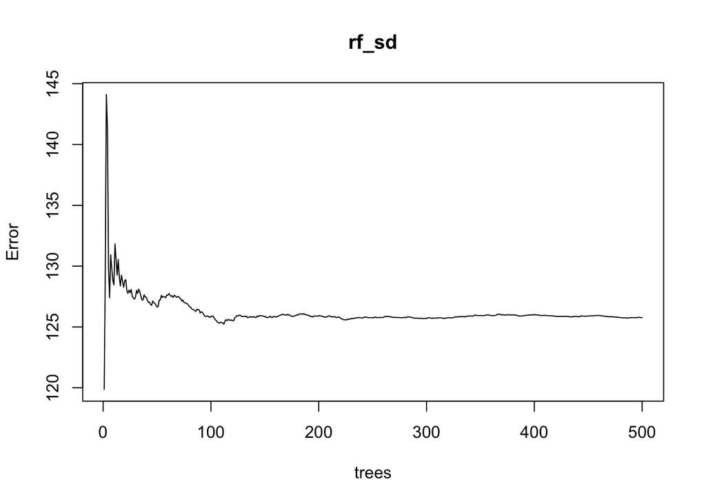

```r
plot(rf_sd)
```

**Afinamiento del modelo Random Forest**

Se define la siguiente grilla de búsqueda:

```r
set.seed(101)
# hyperparameter grid search
hyper_grid_rf <- expand.grid(
  mtry       = seq(1, 15, by = 1),
  node_size  = seq(7, 50, by = 2),
  sampe_size = c(.55, .632, .70, .80),
  OOB_RMSE   = 0
)

# total number of combinations
#nrow(hyper_grid_rf)
```

Se utiliza la librería Ranger para la búsqueda de los mejores hyper parámetros:

```r
for(i in 1:nrow(hyper_grid_rf)) {

  # train model
  model <- ranger(
    formula         = SOLO_DANOS ~ .,
    data            = solo_danos_train,
    num.trees       = 500,
    mtry            = hyper_grid_rf$mtry[i],
    min.node.size   = hyper_grid_rf$node_size[i],
    sample.fraction = hyper_grid_rf$sampe_size[i],
    seed            = 101
  )

  # add OOB error to grid
  hyper_grid_rf$OOB_RMSE[i] <- sqrt(model$prediction.error)
}

hyper_grid_rf %>%
  dplyr::arrange(OOB_RMSE) %>%
  head(10)
```

|  | mtry | node_size | sampe_size | OOB_RMSE |
| --- | --- | --- | --- | --- |
| 1 | 8 | 11 | 0.8 | 10.30059 |
| 2 | 8 | 25 | 0.8 | 10.30190 |
| 3 | 8 | 13 | 0.8 | 10.30192 |
| 4 | 8 | 9 | 0.8 | 10.30204 |
| 5 | 8 | 31 | 0.8 | 10.30206 |
| 6 | 8 | 33 | 0.8 | 10.30212 |
| 7 | 8 | 7 | 0.8 | 10.30216 |
| 8 | 8 | 27 | 0.8 | 10.30231 |
| 9 | 8 | 15 | 0.8 | 10.30247 |
| 10 | 8 | 29 | 0.8 | 10.30250 |

Se ajusta el modelo con los mejores hyper parámetros obtenidos:

```r
set.seed(101)
mejorRandomforest <- randomForest(SOLO_DANOS ~., data = solo_danos_train, mtry = 8, nodesize = 11, ntree = 500, sampe_size= 0.8, importance = TRUE)
mejorRandomforest
```

```
##
## Call:
##  randomForest(formula = SOLO_DANOS ~ ., data = solo_danos_train,      mtry = 8, nodesize = 11, ntree = 500, sampe_size = 0.8, importance = TRUE)
##                Type of random forest: regression
##                      Number of trees: 500
## No. of variables tried at each split: 8
##
##           Mean of squared residuals: 106.0643
##                     % Var explained: 62.55
```

Con la función importance() se extrae la importancia de las variables.

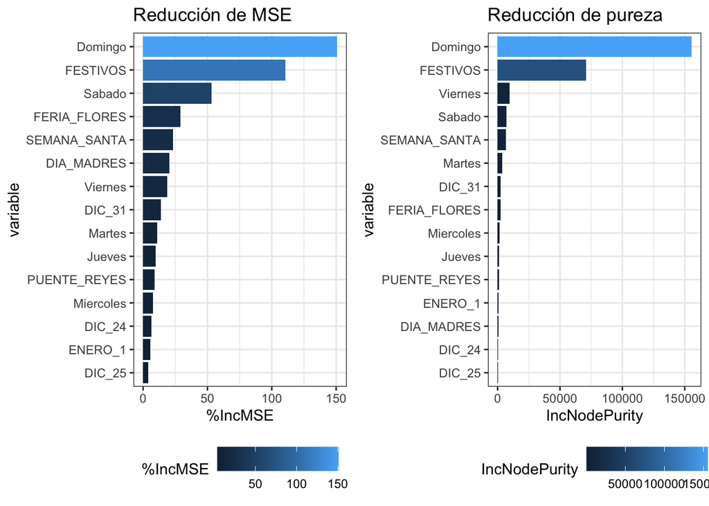

```r
library(tidyverse)
library(ggpubr)
importancia_pred <- as.data.frame(importance(mejorRandomforest, scale = TRUE))
importancia_pred <- rownames_to_column(importancia_pred, var = "variable")
p1 <- ggplot(data = importancia_pred, aes(x = reorder(variable, `%IncMSE`),
                                          y = `%IncMSE`,
                                          fill = `%IncMSE`)) +
    labs(x = "variable", title = "Reducción de MSE") +
    geom_col() +
    coord_flip() +
    theme_bw() +
    theme(legend.position = "bottom")

p2 <- ggplot(data = importancia_pred, aes(x = reorder(variable, IncNodePurity),
                                          y = IncNodePurity,
                                          fill = IncNodePurity)) +
    labs(x = "variable", title = "Reducción de pureza") +
    geom_col() +
    coord_flip() +
    theme_bw() +
    theme(legend.position = "bottom")
ggarrange(p1, p2)
```

**Métricas de bondad para modelo de Random Forest**

```r
pred_randomForest_t <- predict(mejorRandomforest, solo_danos_train)
pred_randomForest <- predict(mejorRandomforest, solo_danos_test)

dt_rf_1 <- data.frame(RMSE_Train = RMSE(pred_randomForest_t, solo_danos_train$SOLO_DANOS),
                    Rsquared_Train = R2(pred_randomForest_t, solo_danos_train$SOLO_DANOS),
                    RMSE_Test = RMSE(pred_randomForest, solo_danos_test$SOLO_DANOS),
                    Rsquared_Test = R2(pred_randomForest, solo_danos_test$SOLO_DANOS))


dt_rf_1
```

| RMSE_Train | Rsquared_Train | RMSE_Test | Rsquared_Test |
| --- | --- | --- | --- |
| 10.13616 | 0.6372575 | 10.86129 | 0.5764182 |